# Motor Trend Analysis

Jesus A. Gonzalez

Monday, June 15, 2015

## Dataset

Our study is based in the **mtcars** (Henderson and Vellemanl, 1981) dataset extacted from the 1974 “Motor Trend US” magazine. This data describes fuel consumption and other aspects of automobile design and performance. The data describes examples of 32 cars from 1973 to 1974. The attributes of the **mtcars** dataset are:

1. mpg, Miles/(US) gallon
2. cyl, Number of cylinders
3. disp, Displacement (cu. in.)
4. hp, Gross horsepower
5. drat, Rear axle ratio
6. wt, Weight (lb/1000)
7. qsec, 1/4 mile time
8. vs, V/S
9. am, Transmission (0 = automatic, 1 = manual)
10. gear, Number of forward gears
11. carb, Number of carburetors

The goal of this analysis is to provide an answer to the question 1 and to provide support to item 2:

1. Is an automatic or manual transmission better for MPG?
2. Quantify the MPG difference between automatic and manual transmissions

## Exploratory Data Analysis

Performing basic exploratory analysis, we observe how, Millage Per Gallon (MPG) is higher for cars with manual transmission than for cars with automatic transmission. This can be seen in plot 1, in which we plot MPG versus AM (the type of transmission being 0 - automatic or 1 - manual) and also considering the difference in number of cylinders. This is better appreciated with the linear model fitted to the points of the plot.

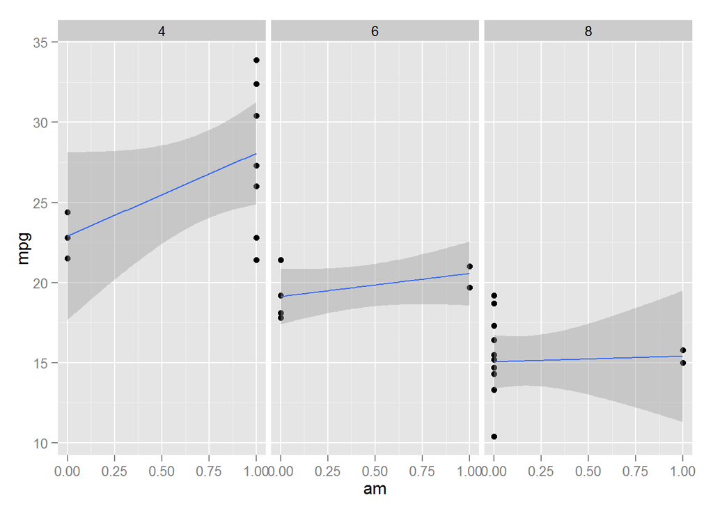

In plot 2, we can observe how MPG varies with respect to the number of cylinders and separating automatic from manual transmission cars. Here we can see a clear difference of how automatic cars have lower MPG. This can be better appreciated with the linear model fitted to the points of the plot.

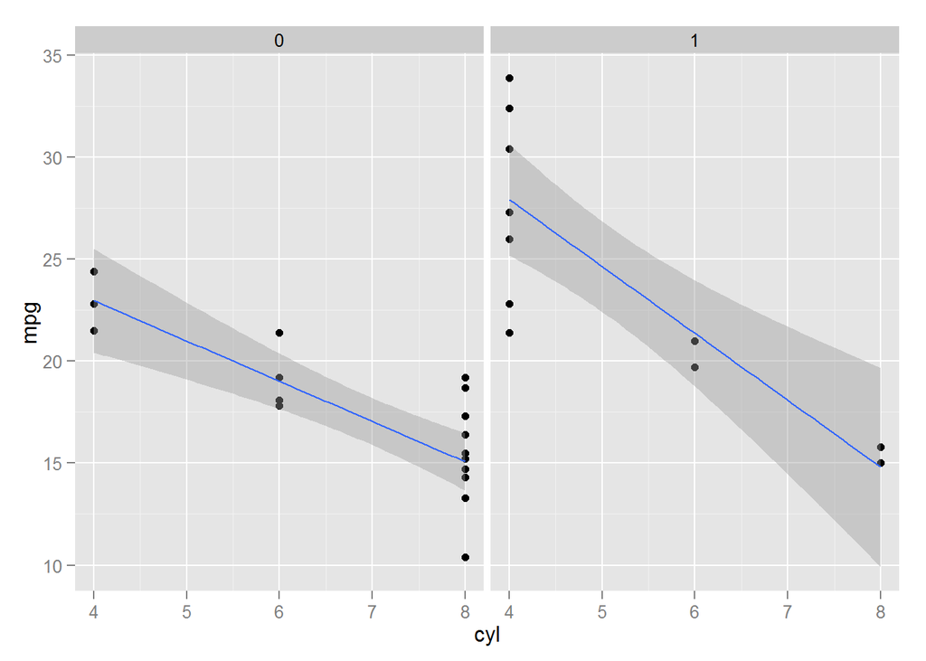

## Experiments

In this section we show the fit of some linear regression models in order to answer the questions.

### Linear Regression MPG with AM

Because **AM** is a binary variable, it does not make much sense to create a linear model with this data, the interpretation of such a model would be incorrect. However, a data transformation of the binary variable (AM) would be necessary in order to create a linear model.

```
##
## Call:
## lm(formula = mpg ~ am, data = mtcars)
##
## Residuals:
##     Min      1Q  Median      3Q     Max
## -9.3923 -3.0923 -0.2974  3.2439  9.5077
##
## Coefficients:
##             Estimate Std. Error t value Pr(>|t|)
## (Intercept)   17.147      1.125  15.247 1.13e-15 ***
## am             7.245      1.764   4.106 0.000285 ***
## ---
## Signif. codes:  0 '***' 0.001 '**' 0.01 '*' 0.05 '.' 0.1 ' ' 1
##
## Residual standard error: 4.902 on 30 degrees of freedom
## Multiple R-squared:  0.3598, Adjusted R-squared:  0.3385
## F-statistic: 16.86 on 1 and 30 DF,  p-value: 0.000285
```

However, as we can see with the exploratory data analysis, automatic transmission vehicles have a lower MPG than manual transmission vehicles.

### Linear Regression to Quantify MPG for Automatic or Manual Transmission

In order to quantify the **MPG** difference between automatic and manual transmission, we separated the dataset in two subsets, one for automatic transmission vehicles and another for manual transmission vehicles.

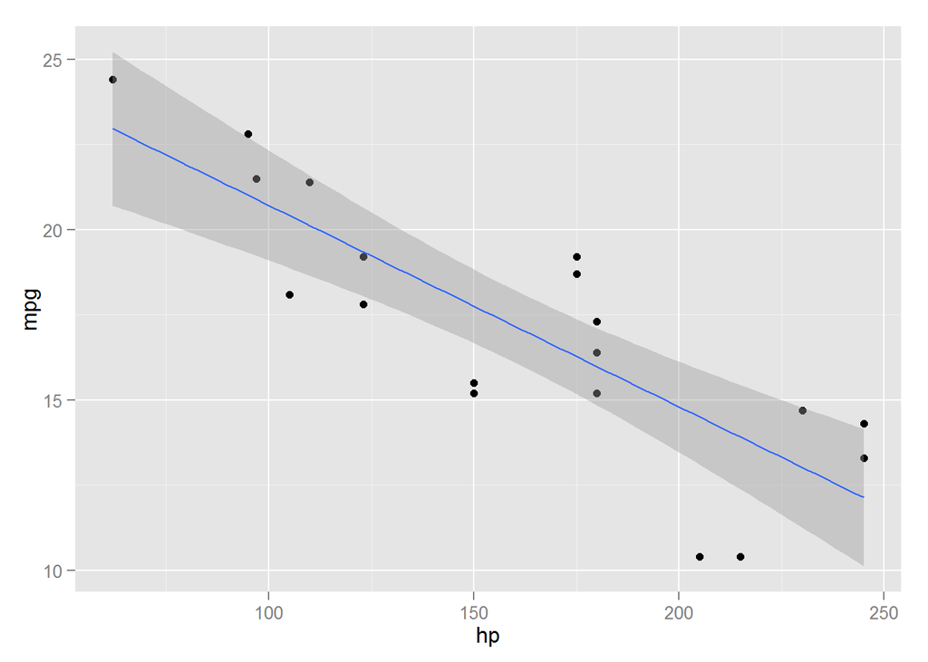

The linear model for **MPG** as the outcome and **hp** as the predictor for automatic vehicles has an intercept at 26.62 and a coefficient of -0.059. This means that for each unit of increase in **MPG** there is a decrement of 0.059 in horse power for automatic vehicles. This linear model is significant with a very low p-value of 6.92e-12 for the intercept and 1.02e-05 for hp.

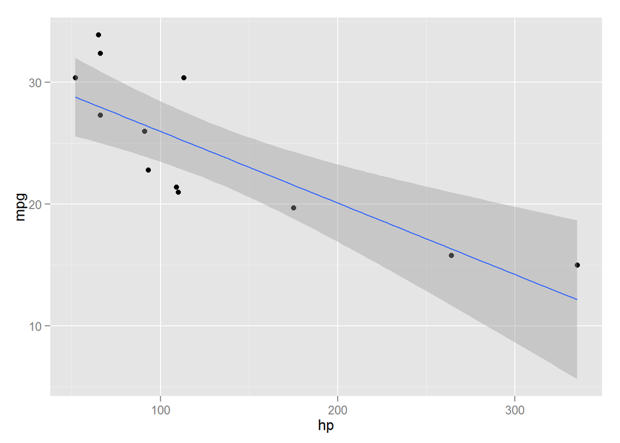

The linear model for **MPG** as the outcome and **hp** as the predictor for **manual** vehicles has an intercept at 31.84 and a coefficient of -0.059. This means that for each unit of increase in **MPG** there is a decrement of 0.059 in horse power for **manual** vehicles. This linear model is significant with a very low p-value of 5.84e-9 for the intercept and 0.001 for hp.

## Residuals Plot for Automatic Cars -MPG - HP-

If we create a residuals plot for **MPG** (the outcome) versus **hp** (the predictor), we find that the variation is in the range of [-4, 3] for the data in our dataset with vehicles with hp between 50 and 250.

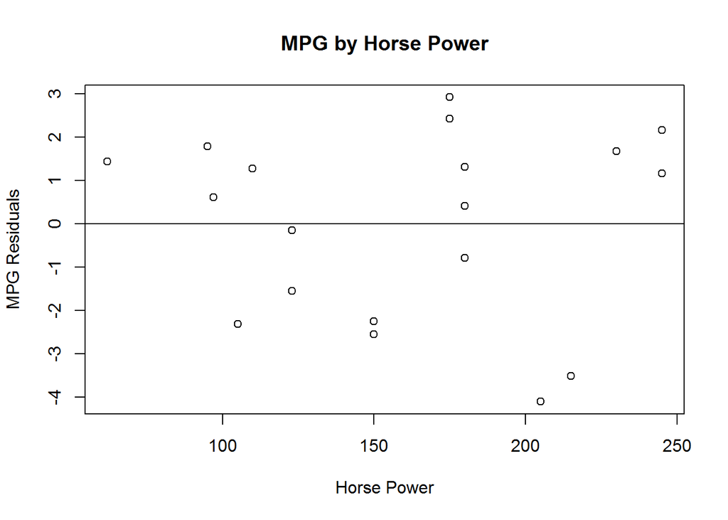

## References

1. Henderson and Velleman, 1981. Building Multiple Regression Models Interactively. Biometrics, 37, 391 - 411.